# A4; incarceration rate

## inequality chart

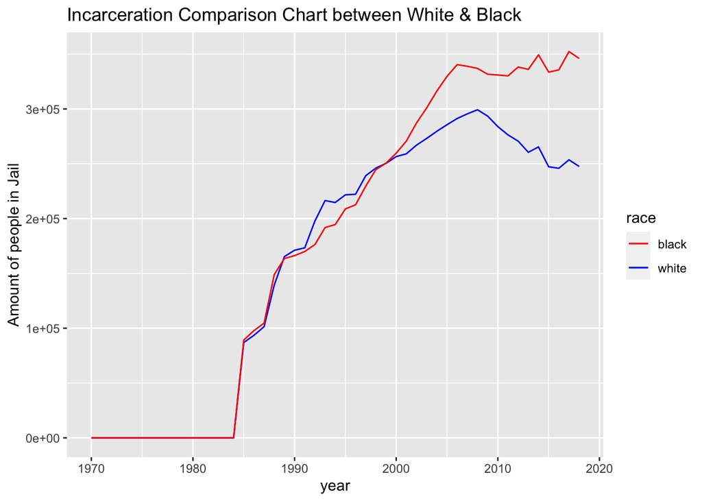

## map

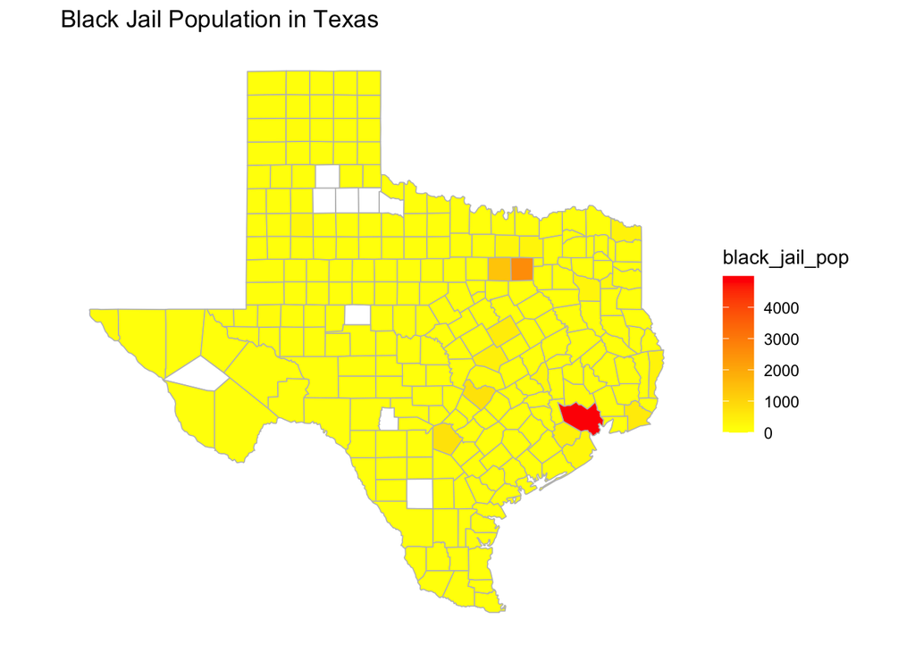

Texas has one of the highest incarceration rates in the nation. In Texas, there are approximately 135 000 prisoners. By dividing the prisoner population by county, it is easier to determine which area has the highest incarceration rate and to inquire whether this is a result of a biased prison system. Based on this map, do we have sufficient evidence to conclude that the system is unequal?